# Music Insights

Olivia Abbott

Tidyverse handles data importing and wrangling:

We also need to load the librarys dplyr and tidyr:

```r
include <- function(library_name){
  if( !(library_name %in% installed.packages()) )
    install.packages(library_name)
  library(library_name, character.only=TRUE)
}

include("tidyverse")
#install.packages("tidyverse")
#library("tidyverse")
#library("dplyr")
#library("tidyr")
```

When importing data use relative paths instead of absolute paths. Use paths reletive to the directory this file is in.

```r
survey <- read_csv("https://raw.githubusercontent.com/introdsci/MusicSurvey/master/music-survey.csv")
preferences <- read_csv("https://raw.githubusercontent.com/introdsci/MusicSurvey/master/preferences-survey.csv")
nrow(survey)
```

```
## [1] 44
```

```r
nrow(preferences)
```

```
## [1] 46
```

Data Cleaning for survey:

Cleaning data column names so that they have a consistant format for the survey table:

```r
#rename_column <- function(data_frame, column_name, new_name){
#  colnames(data_frame)[colnames(data_frame) == column_name] <- new_name
#  }
# this function won't change anything because we pass the dataframe by value not by reference
# in R pass by reference is not supported

colnames(survey)[colnames(survey) == "Timestamp"] <- "time_submitted"
colnames(survey)[colnames(survey) == "First, we are going to create a pseudonym for you to keep this survey anonymous (more or less). Which pseudonym generator would you prefer?"] <- "psuedonym_generator"
colnames(survey)[colnames(survey) == "What is your pseudonym?"] <- "pseudonym"
colnames(survey)[colnames(survey) == "Sex"] <- "sex"
colnames(survey)[colnames(survey) == "Major"] <- "academic_major"
colnames(survey)[colnames(survey) == "Academic Year"] <- "academic_level"
colnames(survey)[colnames(survey) == "Year you were born (YYYY)"] <- "year_born"
colnames(survey)[colnames(survey) == "Which musical instruments/talents do you play? (Select all that apply)"] <- "instrument_list"
colnames(survey)[colnames(survey) == "Artist"] <- "favorite_song_artist"
colnames(survey)[colnames(survey) == "Song"] <- "favorite_song"
colnames(survey)[colnames(survey) == "Link to song (on Youtube or Vimeo)"] <- "favorite_song_link"
colnames(survey)
```

```
##  [1] "time_submitted"       "psuedonym_generator"  "pseudonym"
##  [4] "sex"                  "academic_major"       "academic_level"
##  [7] "year_born"            "instrument_list"      "favorite_song_artist"
## [10] "favorite_song"        "favorite_song_link"
```

Tidy data: We want to split our two tables into 4 tables: 1. Person 2. Favorite Song 3. Song Ratings 4. Musical Talents

To create the person data frame:

```r
person <- tibble(time_submitted = survey$time_submitted, pseudonym_generator = survey$psuedonym_generator, pseudonym = survey$pseudonym, sex = survey$sex, academic_major = survey$academic_major, academic_level = survey$academic_level, year_born = survey$year_born)
```

To create the favarite song data frame:

```r
favorite_song <- tibble(pseudonym = survey$pseudonym, song = survey$favorite_song, artist = survey$favorite_song_artist, link = survey$favorite_song_link)
```

Cleaning the date data so that it is formatted to the POSIXlt format:

```r
library('readr')
?parse_datetime

person$time_submitted <- as.POSIXlt(parse_datetime(person$time_submitted, format = "%m/%d/%y %H:%M"))
```

Cleaning data so that categorical data is represented as factors: (only use as.factor on categorical data)

```r
person$academic_level <- as.factor(person$academic_level)
levels(person$academic_level)
```

```
## [1] "Junior"    "Senior"    "Sophomore"
```

```r
person$academic_major <- as.factor(person$academic_major)
levels(person$academic_major)
```

```
## [1] "Computer Engineering"         "Computer information systems"
## [3] "Computer Information Systems" "Computer Science"
## [5] "Math"
```

```r
# there is an issue with this one since there are different capilalizations of computer information systema
# we need to change the levels so that they are the same category
# change computer information system value
# eliminate other levels so that there is only one computer information systems value
levels(person$academic_major)[levels(person$academic_major) == "Computer information systems"] <-  "Computer Information Systems"
# eliminate other levels so that there is only one computer information systems value
levels(person$academic_major)
```

```
## [1] "Computer Engineering"         "Computer Information Systems"
## [3] "Computer Science"             "Math"
```

Data cleaning for preferences:

Cleaning data column names so that they have a consistant format for the preferences table:

```r
colnames(preferences)[colnames(preferences) == "Timestamp"] <- "time_submitted"
colnames(preferences)[colnames(preferences) == "What was your pseudonym?"] <- "pseudonym"
```

Create Ratings table from the preferences table to make data tidy:

```r
preferences <-  gather(preferences, key = "artist_song", value = "rating", -time_submitted, -pseudonym)
ratings <- tibble(time_submitted = preferences$time_submitted, pseudonym = preferences$pseudonym, artist_song = preferences$artist_song, rating = preferences$rating)
```

Cleaning the date data so that it is formatted to the POSIXlt format:

```r
ratings$time_submitted <- as.POSIXlt(parse_datetime(ratings$time_submitted, format = "%m/%d/%y %H:%M"))
```

Cleaning data so that categorical data is represented as factors: (only use as.factor on categorical data)

```r
ratings$rating <- as.factor(ratings$rating)
levels(ratings$rating)
```

```
##  [1] "1"  "2"  "3"  "4"  "5"  "6"  "7"  "8"  "9"  "10"
```

```r
ratings$artist_song <- as.factor(ratings$artist_song)
levels(ratings$artist_song)
```

```
##  [1] "40 crew\tNot Enough"
##  [2] "Arctic Monkeys Arabella"
##  [3] "Avatar\tThe Eagle Has Landed"
##  [4] "Ben Folds\tStill"
##  [5] "blink-182\tShe's Out Of Her Mind"
##  [6] "brian jonestown massacre / sarabeth tucek\tSeer"
##  [7] "BROCKHAMPTON\tNO HALO"
##  [8] "Brother Ali\tCan't Take That Away"
##  [9] "Daboii\tBeat in a Chokehold"
## [10] "Daniel Caesar\tOpen Up"
## [11] "De La Soul\tPatty Dooke"
## [12] "Dead Kennedys\tKill The Poor"
## [13] "Dominic Fike\t3 Nights"
## [14] "Dream Theater\tA Change of Seasons"
## [15] "Ed Sheeran\tDive"
```

[output cut: 28 more lines]

```r
ratings$pseudonym <- as.factor(ratings$pseudonym)
favorite_song$pseudonym <- as.factor(favorite_song$pseudonym)
levels(favorite_song$pseudonym)
```

```
##  [1] "Angel Angel"         "Aspen War"           "Baddest Burke"
##  [4] "Baddest Veethacheng" "Balla Lincoln"       "Band War"
##  [7] "Boss Marysville"     "Chantel Farm"        "citrus lost"
## [10] "DJ Lakeland"         "Doctor Angeles"      "East Sounds"
## [13] "Edith Empire"        "Eller Angel"         "Heroes War"
## [16] "Hobart Temple"       "Ice Escondido"       "Lassen Farm"
## [19] "Lil"                 "Lil SF"              "Lil' Hills"
## [22] "Lord Los Angeles"    "Magic Stripes"       "Mission Theory"
## [25] "Mulberry Lost"       "Nord Temple"         "Nord War"
## [28] "Prince Ridgecrest"   "Prophet City"        "Prophet Paradise"
## [31] "Puppets War"         "River Angel"         "Rollin' Ridgecrest"
## [34] "Sandy Temple"        "Shooter Bank"        "shooter francisco"
## [37] "Silence"             "Skinny Brentwood"    "Sleezy Jose"
## [40] "Smooth Yuba"         "Theory Party"        "Trace Stripes"
## [43] "West Garden"         "West Magic"
```

```r
levels(ratings$pseudonym)
```

```
##  [1] "Angel Angel"         "Aspen War"           "Baddest Burke"
##  [4] "Baddest Veethacheng" "Balla Lincoln"       "Band War"
##  [7] "Boss Marysville"     "Chantel Farm"        "citrus lost"
## [10] "DJ Lakeland"         "Doctor Angeles"      "East Sounds"
## [13] "Edith Empire"        "Eller Angel"         "Hobart Temple"
## [16] "Ice Escondido"       "Lassen Farm"         "Lil"
## [19] "Lil SF"              "Lil' Hills"          "Lord Los Angeles"
## [22] "Magic Stripes"       "Mission Theory"      "Mulberry Lost"
## [25] "Nord Temple"         "Nord War"            "Prince Ridgecrest"
## [28] "Prophet City"        "Prophet Paradise"    "Puppets War"
## [31] "River Angel"         "Rollin' Ridgecrest"  "Sandy Temple"
## [34] "Shooter Bank"        "shooter francisco"   "Silence"
## [37] "Skinny Brentwood"    "Sleezy Jose"         "Smooth Yuba"
## [40] "Theory Party"        "Trace Stripes"       "West Garden"
## [43] "West Magic"
```

```r
#separate(ratings, artist_song, "song", sep = "([^\t]+)")

#left_join <- left_join(favorite_song, ratings, by = "pseudonym")
#right_join <- right_join(favorite_song, ratings, by = "pseudonym")
#full_join <- full_join(favorite_song, ratings, by = "pseudonym")
#inner_join <- inner_join(favorite_song, ratings, by = "pseudonym")
```

```r
talents <- tibble(pseudonym = survey$pseudonym, instruments = survey$instrument_list)
talents <- separate_rows(talents, -pseudonym, sep = ",")
talents$instruments <- talents$instruments %>%
                        trimws() %>%
                        tolower() %>%
                        str_replace_all(pattern = ".*piano.*", "piano") %>%
                        str_replace_all(patter = ".*ukulele.*", "ukulele") %>%
                        as.factor()
```

Visualizations:

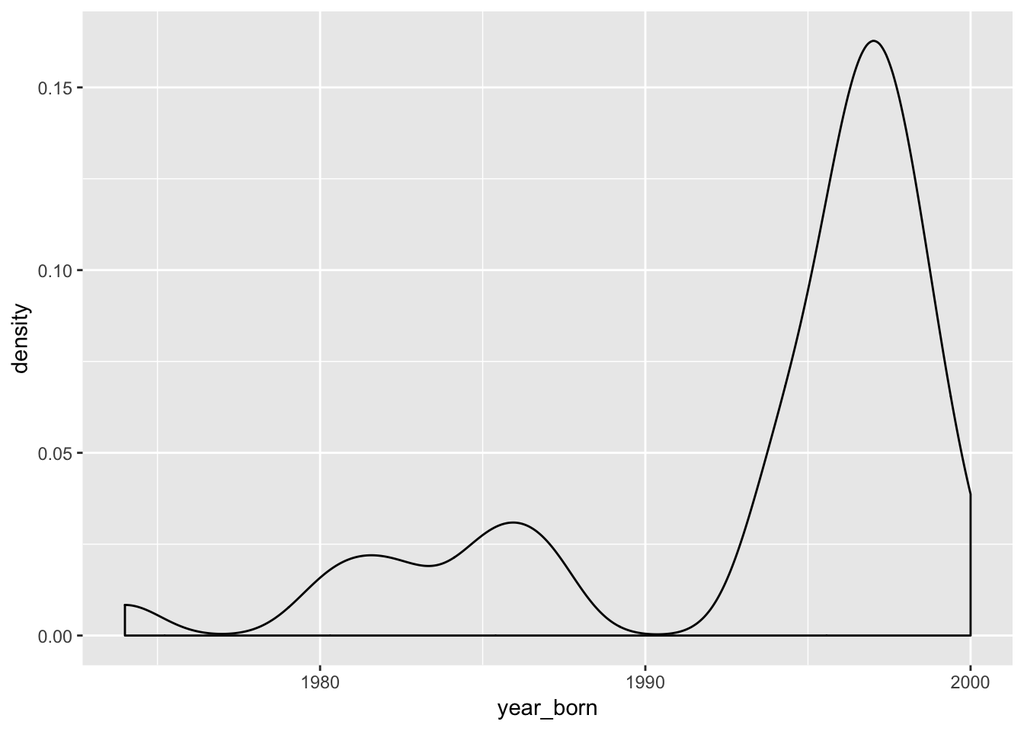

```r
library("ggplot2")

ggplot(person, aes(year_born)) + geom_density()
```

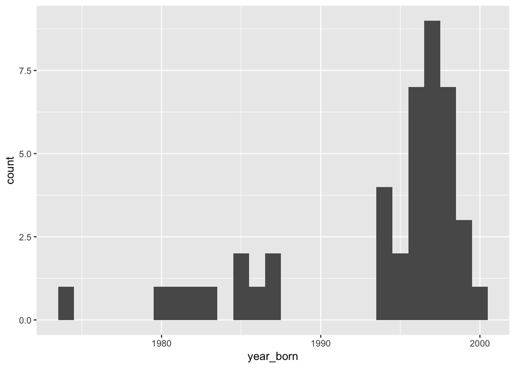

```r
ggplot(person, aes(year_born)) + geom_histogram(binwidth = 1)
```

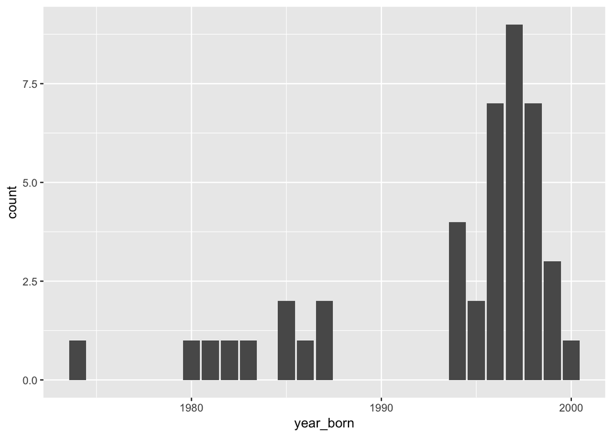

```r
ggplot(person, aes(year_born)) + geom_bar()
```